# PD3

Dominik Rafacz

01 - 04 - 2019

# 1 Wstęp

```r
knitr::kable(head(dat))
```

| TripType | VisitNumber | Weekday | Upc | ScanCount | DepartmentDescription | FinelineNumber |
| --- | --- | --- | --- | --- | --- | --- |
| 999 | 5 | Friday | 68113152929 | -1 | FINANCIAL SERVICES | 1000 |
| 30 | 7 | Friday | 60538815980 | 1 | SHOES | 8931 |
| 30 | 7 | Friday | 7410811099 | 1 | PERSONAL CARE | 4504 |
| 26 | 8 | Friday | 2238403510 | 2 | PAINT AND ACCESSORIES | 3565 |
| 26 | 8 | Friday | 2006613744 | 2 | PAINT AND ACCESSORIES | 1017 |
| 26 | 8 | Friday | 2006618783 | 2 | PAINT AND ACCESSORIES | 1017 |

Dataset na każdą wizytę w supermarkecie (identyfikowaną przez *VisitNumber*) zawiera od jednego do kilku wierszy - każdy wiersz oznacza jeden zakupiony lub zwrócony typ produktu. Wiersz zawiera informację o ID zakupionego produktu (*Upc*), dziale sklepu (*DepartmentDescription*), szczegółowej kategorii produktu (*FinelineNumber*), liczbie kupionych produktów (*ScanCount*, ujemna wartość oznacza zwrócenie produktu), a także infomacje o rodzaju wizyty (*TripType*) i dniu tygodnia (*Weekday*), które są pozostają takie same dla danego *VisitNumber* w obrębie kilku wierszy.

Skuteczność modelu sprawdzać będziemy za pomocą błędu:

$$-\frac{1}{N}\sum_{i=1}^N\sum_{j=1}^k y_{i,j} \log p_{i,j}$$
,

gdzie $N$ oznacza liczbę obserwacji, $k$ liczbę wynikowych klas, $y_{i,j}$ przyjmuje wartość $1$, gdy wizyta nr $i$ jest ma klasę nr $j$, a $0$ w.p.p., natomiast $p_{i,j}$ to zwrócone przez model prawdopodobieństwo, że klasa $i$-tej wizyty ma numer $j$.

Będziemy sprawdzać skuteczność poszczególnych wyborów przez wtyrenowanie lasu losowego na zbiorze treningowym (60% datasetu) i liczyć błąd na testowym (40%).

# 2 Proces generowania

W ramce danych, na której będziemy trenować nasz model, chcemy mieć tylko jeden wiersz na każdą wizytę w sklepie. Musimy więc znaleźć sposób, by zagregować informacje na temat jednej wizyty do jednego wiersza. Z oryginalnych wierszy weźmiemy *TripType* jako nasz target oraz *Weekday* jako jeden z predyktorów. Resztę zmiennych będziemy musieli wygenerować.

Naturalnymi pomysłami są tutaj sumaryczna liczba kupionych produktów oraz liczba różnych kupionych produktów.

**Błąd:**

```r
func1 <- function(dat) {
  dat %>%
    group_by(TripType, Weekday, VisitNumber) %>%
    summarise(DistinctItems = n(), TotalItems = sum(ScanCount)) %>%
    ungroup() %>%
    select(-VisitNumber)
}

dat %>% split_data(func1) %>% do_learning_and_predicting() %>% calculate_error() -> errA
errA
```

```
## [1] 2.309101
```

Kolejnym pomysłem jest zaznaczenie, w których działach klient kupił jakiś produkt. Możemy to zliczyć, wykonując one-hot-encoding na kolumnie *DepartmentDescription*, a następnie, przy grupowaniu po wizytach, wziąć maksimum (czyli wartość 1, gdy klient kupił coś z tego działu lub 0 w przeciwnym przypadku) Moglibyśmy podobnie uczynić z *FinelineNumber*, jednak zbiór wartości tego drugiego jest zdecydowanie zbyt duży i wynikowa ramka byłaby za duża.

**Błąd:**

```r
func2 <- function(dat) {
  cbind(dat, model.matrix(~DepartmentDescription, data = dat)) %>%
    select(-DepartmentDescription, -Upc, -FinelineNumber) %>%
    group_by(TripType, VisitNumber, Weekday) %>%
    summarise_at(vars(matches("DepartmentDescription")), max) -> w2

  dat %>% select(TripType, VisitNumber, Weekday, ScanCount) %>%
    group_by(TripType, VisitNumber, Weekday) %>%
    summarise(DistinctItems = n(), TotalItems = sum(ScanCount)) %>%
    inner_join(w2) %>%
    ungroup() %>%
    select(-VisitNumber)
}


dat %>% split_data(func2) %>% do_learning_and_predicting() %>% calculate_error() -> errB
errB
```

```
## [1] 1.088415
```

Jak widzimy, błąd znacząco spadł, a więc decyzja była dobra.

Naturalnym rozwinięciem poprzedniego pomysłu jest zaznaczanie nie tego, czy podczas wizyty klient odwiedził dany dział, ale ile sumarycznie przedmiotów z niego kupił.

```r
func3 <- function(dat) {
  cbind(dat, model.matrix(~DepartmentDescription, data = dat)) %>%
    select(-DepartmentDescription, -Upc, -FinelineNumber) %>%
    mutate_at(.vars = vars(matches("DepartmentDescription")),
              .funs = list(function(x) x * dat$ScanCount)) %>%
    group_by(TripType, VisitNumber, Weekday) %>%
    summarise_at(vars(matches("DepartmentDescription")), sum) -> w2

  dat %>% select(TripType, VisitNumber, Weekday, ScanCount) %>%
    group_by(TripType, VisitNumber, Weekday) %>%
    summarise(DistinctItems = n(), TotalItems = sum(ScanCount)) %>%
    inner_join(w2) %>%
    ungroup() %>%
    select(-VisitNumber)
}


dat %>% split_data(func3) %>% do_learning_and_predicting() %>% calculate_error() -> errC
errC
```

```
## [1] 1.13164
```

Błąd wzrósł, a więc modyfikację tę możemy cofnąć.

Warto zastanowić się nad jeszcze jednym: ujemnymi wartościami *ScanCount*.

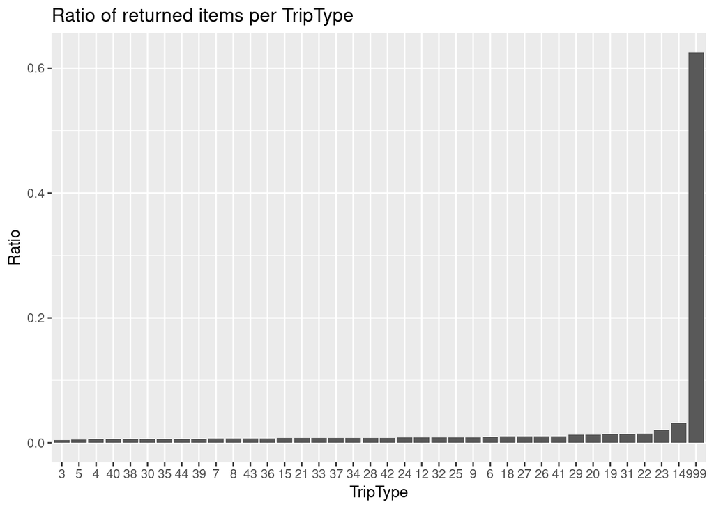

```r
dat %>% mutate(return=if_else(ScanCount <0, 1, 0 )) %>%
  group_by(VisitNumber, TripType) %>%
  summarise(returns = sum(return), items = n())  %>%
  group_by(TripType) %>%
  summarise(ReturnsToTotalRatio = mean(returns/items)) %>%
  ggplot(aes(x=fct_reorder(as.factor(TripType), ReturnsToTotalRatio), y=ReturnsToTotalRatio)) +
  geom_bar(stat="identity") +
  ggtitle("Ratio of returned items per TripType") +
  xlab("TripType") +
  ylab("Ratio")
```

Jak widzimy z powyższego wykresu, typ wizyty “999” ma zdecydowanie większy iloraz zwróconych przedmiotów do wszystkich. Dlatego dodamy do datasetu kolumnę, która będzie ten iloraz przechowywać.

**Błąd:**

```r
func4 <- function(dat) {
  cbind(dat, model.matrix(~DepartmentDescription, data = dat)) %>%
    select(-DepartmentDescription, -Upc, -FinelineNumber) %>%
    mutate(ReturnedItemsCount = if_else(ScanCount<0, -ScanCount, as.integer(0))) %>%
    group_by(TripType, VisitNumber, Weekday) %>%
    mutate_at(vars(matches("DepartmentDescription")), max) %>%
    mutate(ScanCount=sum(ScanCount), ReturnedItemsCount=sum(ReturnedItemsCount)) %>%
    mutate(ReturnedItemsRatio = ReturnedItemsCount/(ScanCount+2*ReturnedItemsCount)) %>%
    select(-ReturnedItemsCount, -ScanCount) %>%
    slice(1L) -> w2

  dat %>% select(TripType, VisitNumber, Weekday, ScanCount) %>%
    group_by(TripType, VisitNumber, Weekday) %>%
    summarise(DistinctItems = n(), TotalItems = sum(ScanCount)) %>%
    inner_join(w2) %>%
    ungroup() %>%
    select(-VisitNumber)
}


dat %>% split_data(func4) %>% do_learning_and_predicting() %>% calculate_error() -> errD
errD
```

```
## [1] 1.085116
```

Poprawa nie jest aż tak duża, jak można by oczekiwać, jednak warto tę kolumnę zachować. Mamy teraz jednak bardzo dużo kolumn. Możemy zastanowić się, czy nie warto zgrupować kilku-kilkunastu kolumn powstałych z one-hot-encodingu *DepartmentDescription*:

```r
dat %>% split_data(func4) -> tmp
tmp$train %>%
  select_at(vars(matches("DepartmentDescription"))) -> tmp
tmp %>%
  summarize_all(.funs = list(mean)) ->tmp2

tmp2 <- data.frame(depart = colnames(tmp2), mean = t(tmp2), row.names = NULL)

knitr::kable(tmp2[tmp2$mean < 0.002,])
```

|  | depart | mean |
| --- | --- | --- |
| 10 | DepartmentDescriptionCAMERAS.AND.SUPPLIES | 0.0018814 |
| 14 | DepartmentDescriptionCONCEPT.STORES | 0.0003832 |
| 26 | DepartmentDescriptionHEALTH.AND.BEAUTY.AIDS | 0.0000348 |
| 38 | DepartmentDescriptionLARGE.HOUSEHOLD.GOODS | 0.0007665 |
| 48 | DepartmentDescriptionOPTICAL…LENSES | 0.0007142 |
| 49 | DepartmentDescriptionOTHER.DEPARTMENTS | 0.0003310 |
| 60 | DepartmentDescriptionSEASONAL | 0.0003310 |

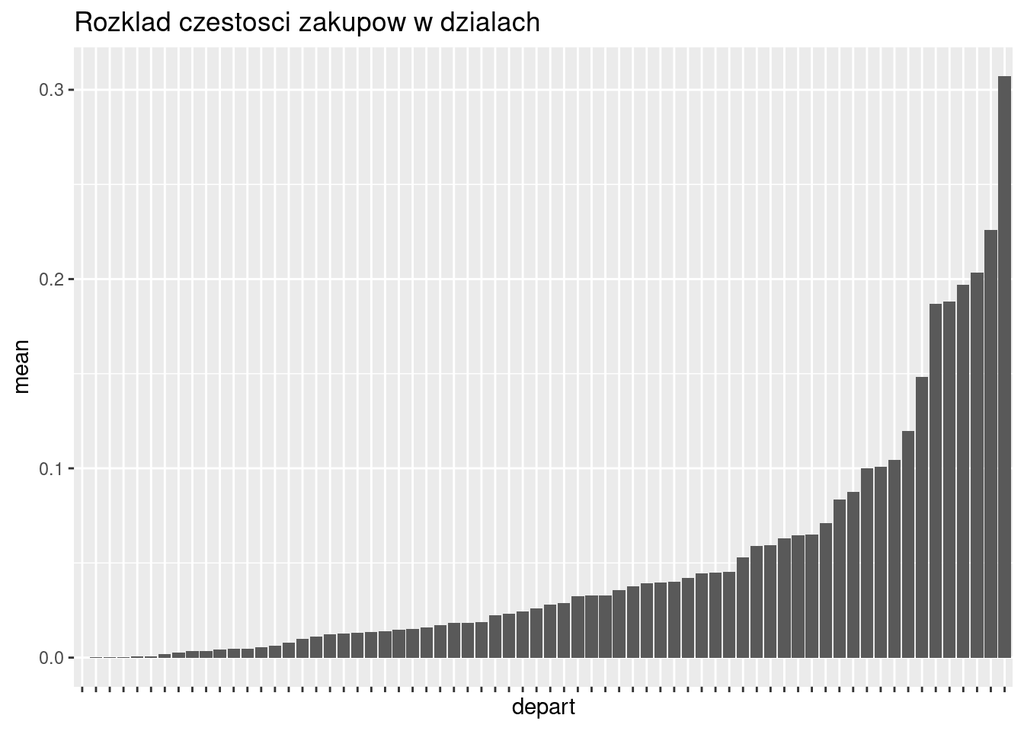

```r
ggplot(data = tmp2 %>% mutate(depart = fct_reorder(depart, mean)), aes(x = depart, y = mean)) +
  geom_bar(stat="identity") +
  ggtitle(label = "Rozklad czestosci zakupow w dzialach") +
  theme(axis.text.x.bottom = element_blank())
```

Spróbujemy teraz zgrupować te kilka zmiennych:

**Błąd:**

```r
func5 <- function(dat) {
  cbind(dat, model.matrix(~DepartmentDescription, data = dat)) %>%
    select(-DepartmentDescription, -Upc, -FinelineNumber) %>%
    mutate(ReturnedItemsCount = if_else(ScanCount<0, -ScanCount, as.integer(0))) -> w1

  colnames(w1) <- make.names(colnames(w1))

  w1 %>%
    mutate(DepartmentDescriptionOTHER =max(
             DepartmentDescriptionOTHER.DEPARTMENTS,
             DepartmentDescriptionCAMERAS.AND.SUPPLIES,
             DepartmentDescriptionOPTICAL...LENSES,
             DepartmentDescriptionCONCEPT.STORES,
             DepartmentDescriptionLARGE.HOUSEHOLD.GOODS,
             DepartmentDescriptionSEASONAL,
             DepartmentDescriptionHEALTH.AND.BEAUTY.AIDS)) %>%
    group_by(TripType, VisitNumber, Weekday) %>%
    mutate_at(vars(matches("DepartmentDescription")), max) %>%
    mutate(ScanCount=sum(ScanCount), ReturnedItemsCount=sum(ReturnedItemsCount)) %>%
    mutate(ReturnedItemsRatio = ReturnedItemsCount/(ScanCount+2*ReturnedItemsCount)) %>%
    select(-ReturnedItemsCount, -ScanCount) %>%
    slice(1L)-> w2

  dat %>% select(TripType, VisitNumber, Weekday, ScanCount) %>%
    group_by(TripType, VisitNumber, Weekday) %>%
    summarise(DistinctItems = n(), TotalItems = sum(ScanCount)) %>%
    inner_join(w2) %>%
    ungroup() %>%
    select(-VisitNumber,
           -DepartmentDescriptionOTHER.DEPARTMENTS,
           -DepartmentDescriptionCAMERAS.AND.SUPPLIES,
           -DepartmentDescriptionOPTICAL...LENSES,
           -DepartmentDescriptionCONCEPT.STORES,
           -DepartmentDescriptionLARGE.HOUSEHOLD.GOODS,
           -DepartmentDescriptionSEASONAL,
           -DepartmentDescriptionHEALTH.AND.BEAUTY.AIDS)
}


dat %>% split_data(func5) %>% do_learning_and_predicting() %>% calculate_error() -> errE
errE
```

```
## [1] 1.085958
```

Błąd zwiększył się odrobinę, ale w granicach błedu statystycznego, natomiast liczba kolumn się zmniejszyła, więc warto zachować ten zestaw zmmiennych.

# 3 Podsumowanie